# chapter2 - vectors

alfonso

April 9, 2016

| operations | meaning |
| --- | --- |
| Recycling | 在特定的设置下自动增长 |
| Filtering | 提取出vector的子集 |
| Vectorization | 作用于每个vector的元素的函数 |

# 基本操作

危险的类型变化：

```r
y <- vector(length = 2)
y
```

```
## [1] FALSE FALSE
```

```r
y[3] <- 122
y
```

```
## [1]   0   0 122
```

## recycling与`rep`函数

当一个操作需要两个等长的`vector`时，R会自动地`recycle`短的那个`vector`。

```r
c(1,2,4) + c(6,0,9,20,22) == c(1,2,4,1,2) + c(6,0,9,20,22)
```

```
## [1] TRUE TRUE TRUE TRUE TRUE
```

```r
x <- cbind(c(1, 2, 3), c(4, 5, 6))
x
```

```
##      [,1] [,2]
## [1,]    1    4
## [2,]    2    5
## [3,]    3    6
```

```r
x + c(1, 2)
```

```
##      [,1] [,2]
## [1,]    2    6
## [2,]    4    6
## [3,]    4    8
```

```r
x + c(1, 2, 3)
```

```
##      [,1] [,2]
## [1,]    2    5
## [2,]    4    7
## [3,]    6    9
```

```r
x + c(1, 2, 1, 2, 1, 2)
```

```
##      [,1] [,2]
## [1,]    2    6
## [2,]    4    6
## [3,]    4    8
```

`rep(x, times/each)`函数：

```r
x <- rep(8, 4)
x
```

```
## [1] 8 8 8 8
```

```r
rep(c(5, 12, 13), 3)
```

```
## [1]  5 12 13  5 12 13  5 12 13
```

```r
rep(c(5,12,13),each=3)
```

```
## [1]  5  5  5 12 12 12 13 13 13
```

## 算术和逻辑操作

```r
2+3
```

```
## [1] 5
```

```r
"+"(2, 3)
```

```
## [1] 5
```

```r
x <- c(1, 2, 4)
x %% c(5, 4, 1)
```

```
## [1] 1 2 0
```

## 索引（下标）操作

```r
y <- c(1.2,3.9,0.4,0.12)
y[c(1, 3)]
```

```
## [1] 1.2 0.4
```

```r
y[1:3]
```

```
## [1] 1.2 3.9 0.4
```

下标前的`-`表示去掉该元素：

```r
z <- c(5,12,13)
z[-1]
```

```
## [1] 12 13
```

```r
z[-1:-2]
```

```
## [1] 13
```

```r
z[-length(z)]
```

```
## [1]  5 12
```

```r
z[-1] <- 2 # 将所有元素置为2，除了第一个元素
```

## `:`操作符与`seq`函数

`a:b`根据`a,b`的相对大小来确定是递增还是递减：

```r
5:8
```

```
## [1] 5 6 7 8
```

```r
5:1
```

```
## [1] 5 4 3 2 1
```

`:`的优先级比`-`高

```r
i <- 2
1:i-1
```

```
## [1] 0 1
```

```r
1:(i-1)
```

```
## [1] 1
```

```r
# 优先级表
?Syntax
```

`seq`函数：

```r
seq(from=12,to=30,by=3)
```

```
## [1] 12 15 18 21 24 27 30
```

```r
seq(from=1.1,to=2,length=10)
```

```
##  [1] 1.1 1.2 1.3 1.4 1.5 1.6 1.7 1.8 1.9 2.0
```

```r
x <- c(5, 9, 12)
seq_along(x) # seq(x) seq_along 更快
```

```
## [1] 1 2 3
```

## `all, any`函数

```r
x <- 1:10
x > 8
```

```
##  [1] FALSE FALSE FALSE FALSE FALSE FALSE FALSE FALSE  TRUE  TRUE
```

```r
any(x > 8)
```

```
## [1] TRUE
```

```r
all(x > 8)
```

```
## [1] FALSE
```

# example

## 找到序列`x`中`k`个连续的1出现的索引（`x`只由`0,1`组成）

```r
findruns1 <- function(x, k) {
  n <- length(x)
  runs <- NULL
  for(i in 1:(n-k+1)) {
    if(all(x[i:(i+k-1)] == 1)) runs <- c(runs, i)
  }
  return(runs)
}
findruns1(c(1,0,0,1,1,1,0,1,1),2)
```

```
## [1] 4 5 8
```

带有优先内存配的`findruns`：

```r
findruns2 <- function(x, k) {
  n <- length(x)
  runs <- vector(length = n)
  count <- 0
  for(i in 1:(n-k+1)) {
    if(all(x[i:(i+k-1)] == 1)) {
      count <- count + 1
      runs[count] <- i
    }
  }

  if(count > 0) {
    runs <- runs[1:count]
  } else {
    runs <- NULL
  }
  return(runs)
}
```

上述方法调用`all`函数会造成序列的重复扫描，由于这个问题的特殊性，不需要每次调用`all`来处理。

```r
findruns3 <- function(x, k) {
  n <- length(x)
  runs <- vector(length = n)
  count <- 0
  i <- 1
  for(j in 1:n) {
    if(x[j] == 1) {
      if((j-i) == (k-1)){
        count <- count + 1
        runs[count] <- i
        i <- i + 1
      }
    } else {
      i <- j + 1   # 只有两处地方修改i的值
    }
  }

  if(count > 0) {
    runs <- runs[1:count]
  } else {
    runs <- NULL
  }
  return(runs)
}
```

```r
# test case
x <- c(1, 0, 0, 1, 1, 1, 0, 1, 1)
for(k in 1:length(x)) {
  if(all(findruns1(x, k) == findruns3(x, k))) {
    print("ok")
  } else {
    print("something wrong!!")
  }
}
```

```
## [1] "ok"
## [1] "ok"
## [1] "ok"
## [1] "ok"
## [1] "ok"
## [1] "ok"
## [1] "ok"
## [1] "ok"
## [1] "ok"
```

## 预测离散值类型的时间序列

现有按天生成的0，1序列`x`（1表示下雨，0表示没下雨），我们要推断明天是否下雨。推断依据是 如果最近的`k`天中有一半以上下雨则明天下雨，否则明天不下雨。现在是如果根据训练集来确定比较好 的`k`值。

```r
preda1 <- function(x, k) {
  n <- length(x)
  k2 <- k / 2
  pred <- vector(length = n-k)
  for(i in 1:(n-k)) {
    if(sum(x[i:(i+(k-1))]) >= k2) pred[i] <- 1 else pred[i] <- 0
  }
  return(mean(abs(pred - x[(k+1):n])))
}
```

`sum`函数的多次调用可以避免掉：

```r
pred2 <- function(x, k) {
  n <- length(x)
  k2 <- k / 2
  pred <- vector(length = n-k)
  sm <- sum(x[1:k])
  for(i in 1:(n-k)){
    if(sm >= k2) {
      pred[i] <- 1
    } else {
      pred[i] <- 0
    }
    sm <- sm - x[i] + x[i+k]
  }
  return(mean(abs(pred - x[(k+1):n])))
}
####      原书代码
predb <- function(x,k) {
  n <- length(x)
  k2 <- k/2
  pred <- vector(length=n-k)
  sm <- sum(x[1:k])

  if (sm >= k2) pred[1] <- 1 else pred[1] <- 0
  if (n-k>=2){
    for (i in 2:(n-k)) {
      sm <- sm + x[i+k-1] - x[i-1]
      if (sm >= k2) pred[i] <- 1 else pred[i] <- 0
    }
  }
  return(mean(abs(pred-x[(k+1):n])))
}
```

使用R内置的`cumsum`来替代累积求和的相关代码：

```r
y <- c(5,2,-3,8)
cumsum(y)
```

```
## [1]  5  7  4 12
```

```r
pred3 <- function(x, k) {
  n <- length(x)
  k2 <- k/2
  pred <- vector(length=n-k)
  csx <- c(0, cumsum(x))  # !!
  for(i in 1:(n-k)){
    if((csx[i+k]-csx[i]) >= k2) pred[i] <- 1 else pred[i] <- 0
  }
  return(mean(abs(pred-x[(k+1):n])))
}
```

# Vectorized Operations（基于元素的操作）

## Vector In, Vector Out

前面介绍的操作都有涉及到标题，输出类型都是`vector`

## Vector In, Matrix Out

用`vector`生成`matrix`

```r
z12 <- function(z) return(c(z,z^2))
x <- 1:8
z12(x)
```

```
##  [1]  1  2  3  4  5  6  7  8  1  4  9 16 25 36 49 64
```

```r
# 生成matrix
# 显示调用matrix函数
matrix(z12(x),ncol=2)
```

```
##      [,1] [,2]
## [1,]    1    1
## [2,]    2    4
## [3,]    3    9
## [4,]    4   16
## [5,]    5   25
## [6,]    6   36
## [7,]    7   49
## [8,]    8   64
```

```r
# 用cbind,rbind拼一个
cbind(z12(x)[1:length(x)], z12(x)[-(1:length(x))])
```

```
##      [,1] [,2]
## [1,]    1    1
## [2,]    2    4
## [3,]    3    9
## [4,]    4   16
## [5,]    5   25
## [6,]    6   36
## [7,]    7   49
## [8,]    8   64
```

```r
# sapply
sapply(1:8, z12)
```

```
##      [,1] [,2] [,3] [,4] [,5] [,6] [,7] [,8]
## [1,]    1    2    3    4    5    6    7    8
## [2,]    1    4    9   16   25   36   49   64
```

# `NA` vs `NULL`

> `NA`表示存在这个值，但我们不知道是多少  
> `NULL`表示不存在这个值  
> `NA`是一个值，它的类型可以根据同组的其它元素而得知，而`NULL`不是一个值

```r
x <- c(88,NA,12,168,13)
mean(x)
```

```
## [1] NA
```

```r
mean(x,na.rm=T)
```

```
## [1] 70.25
```

```r
x <- c(88,NULL,12,168,13)
mean(x)
```

```
## [1] 70.25
```

`NULL`可用在初始化一个空`vector`，这点在前面的代码可以看到。如果在该用`NULL`的地方用了`NA`，就会有惊喜（`NA`被当做一个占位符）。

```r
z <- NULL
for (i in 1:10) if (i %%2 == 0) z <- c(z,i)
z
```

```
## [1]  2  4  6  8 10
```

```r
z <- NA
for (i in 1:10) if (i %%2 == 0) z <- c(z,i)
z
```

```
## [1] NA  2  4  6  8 10
```

```r
u <- NULL
length(u)
```

```
## [1] 0
```

```r
v <- NA
length(v)
```

```
## [1] 1
```

# Filter

## 使用下标（TRUE,FALSE向量）来过滤

```r
z <- c(5,2,-3,8)
z <- z[z*z > 8] # filter self
j <- z*z > 8
y <- c(1,2,30,5)
y[j] # filter other
```

```
## [1]  1  2 30  5
```

过滤 + 赋值

```r
x <- c(1,3,8,2,20)
x[x > 3] <- 0
x
```

```
## [1] 1 3 0 2 0
```

## 使用`subset`函数过滤

subset自动过滤`NA`，等同于`x[subset & !is.na(subset)]`

```r
x <- c(6,1:3,NA,12)
x[x > 5]
```

```
## [1]  6 NA 12
```

```r
subset(x,x > 5)
```

```
## [1]  6 12
```

## `which`获取过滤后元素在原数据中的下标

```r
z <- c(5,2,-3,8)
which(z*z > 8)
```

```
## [1] 1 3 4
```

# 加强版`if-then-else => ifelse`作用于每个元素

```r
x <- 1:10
y <- ifelse(x %% 2 == 0,5,12) # %% is the mod operator
y
```

```
##  [1] 12  5 12  5 12  5 12  5 12  5
```

如果没有这个加强版，以上代码得这样：

```r
x <- 1:10
myfun <- function(x) {
  if(x %% 2 == 0) y <- 5 else y <- 12
}
sapply(x, myfun)
```

```
##  [1] 12  5 12  5 12  5 12  5 12  5
```

```r
y
```

```
##  [1] 12  5 12  5 12  5 12  5 12  5
```

嵌套版：

```r
g <- c("M", "F", "F", "I", "M", "M", "F")
a <- ifelse(g == "F", 2, 3)
a
```

```
## [1] 3 2 2 3 3 3 2
```

```r
ifelse(g == "M", 1, a)
```

```
## [1] 1 2 2 3 1 1 2
```

```r
ifelse(g == "M", 1, ifelse(g == "F", 2, 3))
```

```
## [1] 1 2 2 3 1 1 2
```

# example2

## 相关性度量

两个变量（例如：温度和气压）同步调变化的平均数

```r
# 生成增减标示向量，1表增加，－1表下降
findud <- function(v) {
  vud <- v[-1] - v[-length(v)]
  return(ifelse(vud > 0, 1, -1))
}

udcorr <- function(x, y) {
  ud <- lapply(list(x, y), findud)
  return(mean(ud[[1]] == ud[[2]]))
}

x <- c(1, 3, 2, 5, 4)
y <- c(3, 1, 2, 5, 4)
udcorr(x, y)
```

```
## [1] 0.5
```

```r
lapply(list(x, y), findud)
```

```
## [[1]]
## [1]  1 -1  1 -1
##
## [[2]]
## [1] -1  1  1 -1
```

浓缩版：

```r
udcorr <- function(x, y) mean(sign(diff(x)) == sign(diff(y)))
```

## 分组绘图

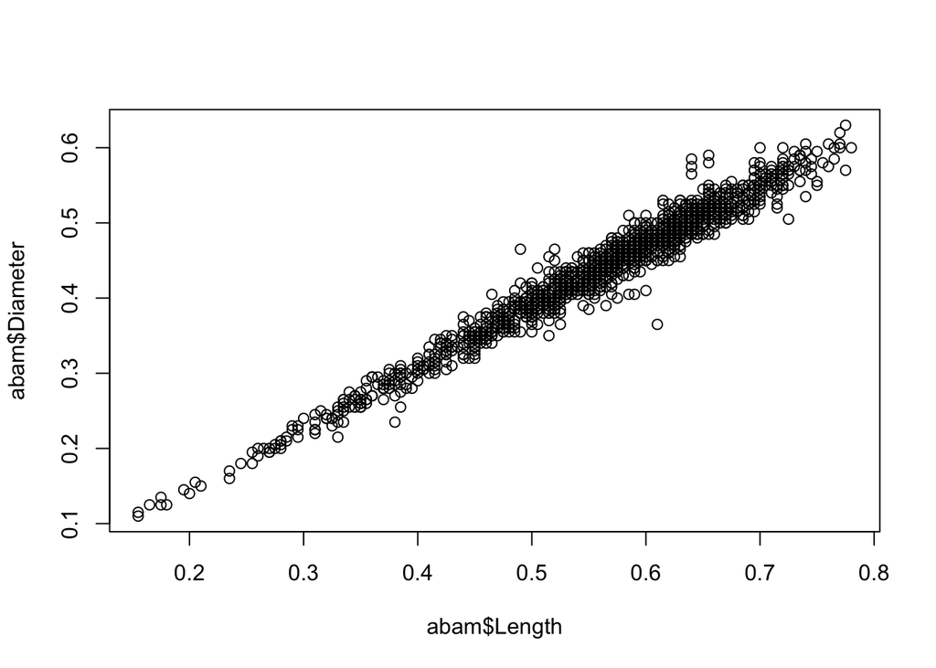

```r
aba <- read.csv("data/Abalone.data")
grps <- list()
for (gen in c("M","F")) grps[[gen]] <- which(aba==gen)
abam <- aba[grps$M,]
abaf <- aba[grps$F,]
plot(abam$Length,abam$Diameter)
```

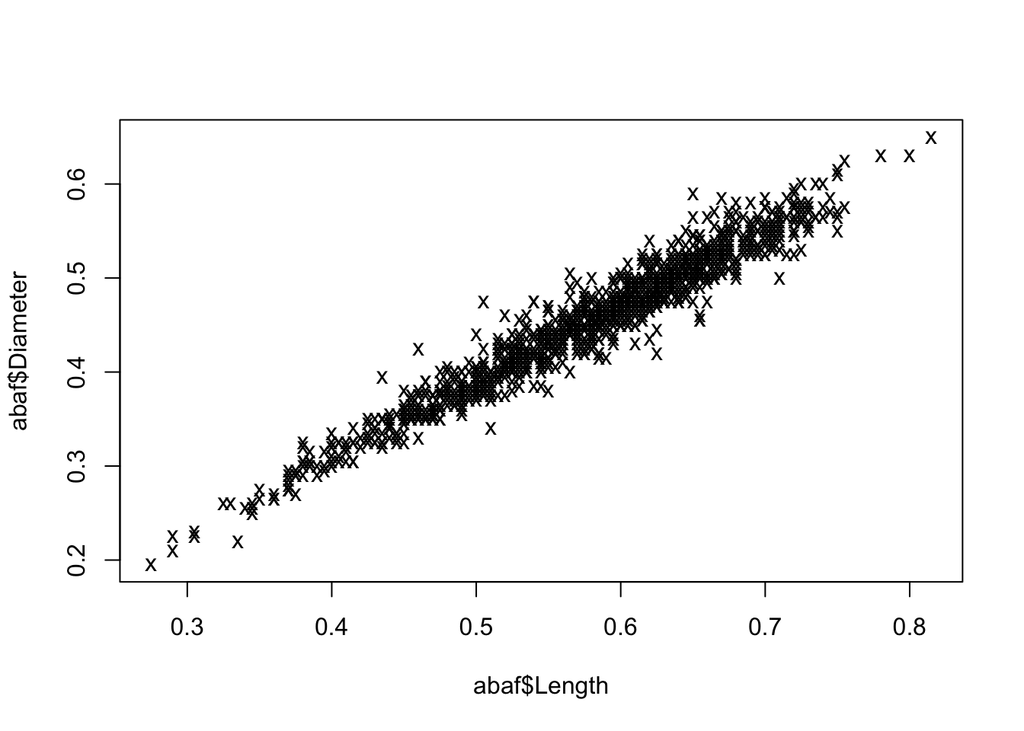

```r
plot(abaf$Length,abaf$Diameter,pch="x",new=FALSE)
```

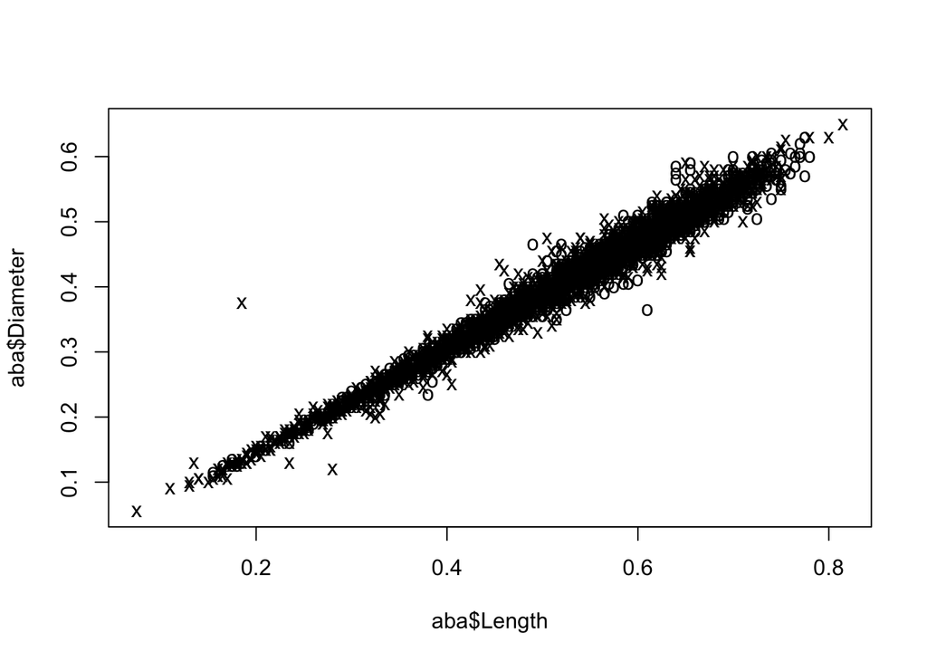

```r
## 浓缩版
pchvec <- ifelse(aba$Gender == "M","o","x")
plot(aba$Length,aba$Diameter,pch=pchvec)
```

# vector的比较

传统的`==`函数返回的是`vector`，里面的元素是`logical`，而我们想要的是`logical`。

```r
# 方法一
x <- 1:3
y <- c(1,3,4)
all(x == y)
```

```
## [1] FALSE
```

```r
x <- 1:3
y <- c(1,2,3)
all(x == y)
```

```
## [1] TRUE
```

```r
# 方法二 !! 慎用
x <- 1:3
y <- c(1,3,4)
identical(x, y)
```

```
## [1] FALSE
```

```r
x <- 1:3
y <- c(1,2,3)
identical(x, y)
```

```
## [1] FALSE
```

```r
# !!!!! 这里出问题了
typeof(x)
```

```
## [1] "integer"
```

```r
typeof(y)
```

```
## [1] "double"
```

# 给`vector`的每个元素起名字

```r
x <- c(1,2,4)
names(x)
```

[output not shown]

```r
names(x) <- c("a","b","ab")
names(x)
```

```
## [1] "a"  "b"  "ab"
```

```r
names(x) <- c("a","b") # 给某个忘了起名字
```

# `c`函数深探

自动处理类型：

```r
c(5,2,"abc")
```

```
## [1] "5"   "2"   "abc"
```

```r
c(5,2,list(a=1,b=4))
```

```
## [[1]]
## [1] 5
##
## [[2]]
## [1] 2
##
## $a
## [1] 1
##
## $b
## [1] 4
```

```r
c(5,"2",list(a=1,b=4))
```

```
## [[1]]
## [1] 5
##
## [[2]]
## [1] "2"
##
## $a
## [1] 1
##
## $b
## [1] 4
```

```r
c(5,2,c(1.5,6)) # flatten
```

```
## [1] 5.0 2.0 1.5 6.0
```